*Licenciatura en ciencias genomicas - Curso de estadística con R 2021*

**Salvador Gonzalez Juarez**

# Tarea 3: Expresión génica

### El objetivo de esta tarea es que simulen datos de expresión de genes en dos condiciones diferentes y con 15 réplicas para cada gen y condición. Despúes visualizaran los datos mediante gráficas.

**(1 punto) Ejercicio 1: Genera un conjunto de 50,000 genes con nombres (gene1, …, gene50,000). Para cada gen escoge una categoría: Activador, Represor o Ambivalente, con probabilidades 0.5, 0.4 y 0.1 respectivamente.**

```r
# Creo el conjunto de los nombres de los genes
n_genes <- 1:50000
genes <- c(paste("gene", n_genes, sep=""))

# Creo un conjunto con la categoria respectiva para cada gen, y asocio ambos conjuntos en un data frame.
categoria <- sample(c("Activador", "Represor", "Ambivalente"), size=length(n_genes), replace=TRUE, prob=c(0.5, 0.4, 0.1))
info_genes <- data.frame("Gen"=genes, "Categoria"=categoria)

# Imprimo la informacion de los primeros diez genes
head(info_genes, 10)
```

```
##       Gen   Categoria
## 1   gene1 Ambivalente
## 2   gene2    Represor
## 3   gene3   Activador
## 4   gene4   Activador
## 5   gene5    Represor
## 6   gene6   Activador
## 7   gene7    Represor
## 8   gene8   Activador
## 9   gene9   Activador
## 10 gene10    Represor
```

**(4 puntos) Ejercicio 2: Genera los valores de expresión de los 50,000 genes para cada una de las 15 réplicas de cada condición. Para cada gen y cada condición debes generar 15 valores aleatorios de una distribución Normal con media *μ=M* y desviación estándar *sd=M/2*, donde *M* es un valor distinto para cada pareja gen/condición y es escogido al azar de una distribución *Gamma* con parámetros *shape=5* y *scale=2*.**

```r
# La siguiente funcion retorna una matriz con los valores de expresion de cada gen en 15 condiciones
obtener_expresion <- function(x){

  # Calculo el valor de M para cada gen
  M = rgamma(x, shape=5, scale=2)

  # Calculo el valor de expresion para las 15 condiciones de un solo gen
  condicion <- sapply(M, function(M){
    rnorm(15, mean=M, sd=(M/2))})

  # Retorna la matriz resultante
  return(condicion)
}

# Obtengo un array tridimencional con la informacion de expresion de cada gen en las dos condiciones
expresion <- array(c(obtener_expresion(n_genes), obtener_expresion(n_genes)), c(15,length(n_genes),2))

# Imprimo los valores de expresion del gen1 en cada condicion
expresion[,1,]
```

```
##            [,1]      [,2]
##  [1,]  3.430592  4.484246
##  [2,]  6.704032  8.585610
##  [3,] 23.993880  6.102135
##  [4,] 24.055775  7.249750
##  [5,] 21.270093  5.471468
##  [6,] 23.497980  4.837831
##  [7,] 13.622545  9.136721
##  [8,] 24.097768  5.419260
##  [9,]  5.363434  4.814132
## [10,]  9.959401  5.153057
## [11,] 20.201552  1.576210
## [12,] 22.680569  4.090159
## [13,] 21.751619 11.066345
## [14,] 18.681030 -1.213272
## [15,] 18.616046  2.209497
```

**(1 punto) Ejercicio 3: En este momento para cada gen debes tener 30 valores de expresión, 15 para la condición 1 y 15 para la condición 2. Escoge 30 genes al azar y gráfica la dinámica de expresión de estos 30 genes dentro de la misma figura, tomando al eje X como el tiempo y al eje Y como los valores de expresión (estamos suponiendo que los 30 valores de expresión corresponden a mediciones a lo largo del tiempo). Ver la ayuda las funciones *plot* y *lines*, incluyendo el parámetro *ylim* para asegurarte que el rango de todos los valores de expresión estén contenidos en la figura.**

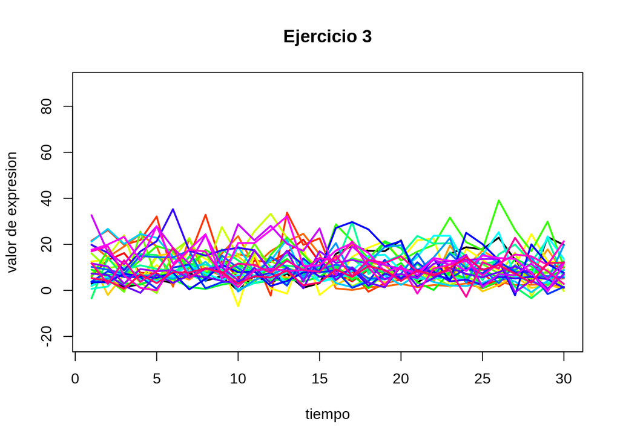

```r
# Selecciono 30 genes de forma aleatoria
n_selec <- 30
genes_selec <- sample(n_genes, size=n_selec, replace=FALSE)

# Grafico la dinamica de expresion de un solo gen
plot(1:30, expresion[, genes_selec[1], ],

     # Modifico las caracteristicas de las lineas
     type='l', col='black', lwd=2, main='Ejercicio 3',

     # Modifico los limites de la grafica
     ylim=c(min(expresion), max(expresion)),

     # Modifico la documentacion de la grafica
     xlab='tiempo', ylab='valor de expresion')

# Creo un vector con un numero de colores equivalente al numero de genes seleccionados
colors <- rainbow(n_selec)

# Grafico la dinamica de expresion de los demas genes, con sus respectivos colores
i = 1
for (n in genes_selec[2:n_selec]) {
  lines(1:30, expresion[, n, ], col=colors[i], lwd=2)
  i = i + 1
}
```

**(1 punto) Ejercicio 4: Haz un heatmap con la dinámica de expresión de los 30 genes escogidos en el inciso anterior, donde los renglones correspondan a los genes y las columnas a los 30 niveles de expresión. Ver la ayuda de la función *heatmap*.**

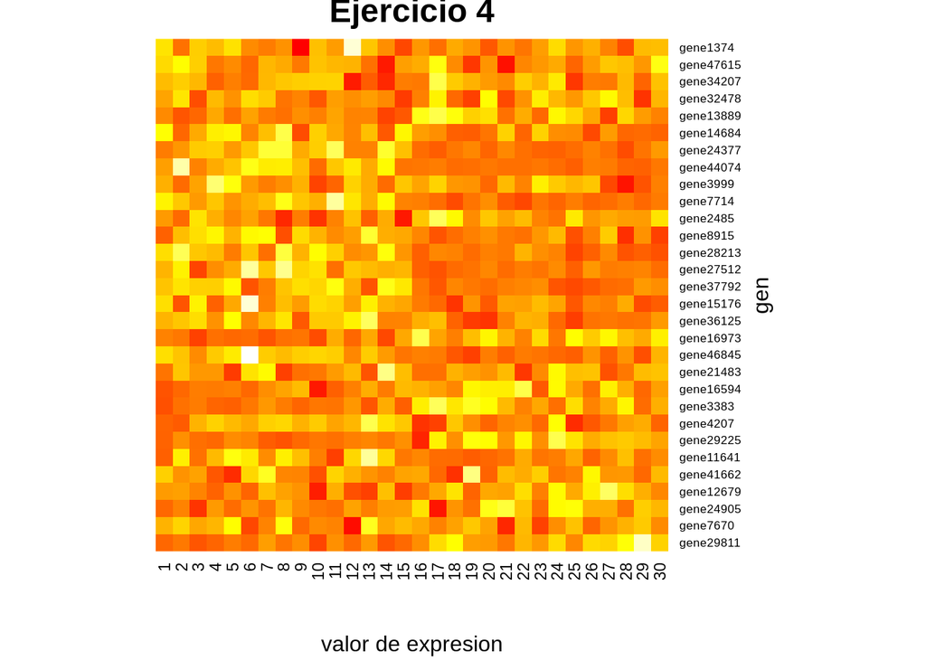

```r
# Creo un heatmap de la dinamica de expresion de los genes seleccionados anteriormente
heatmap(

  # Condenso la informacion de ambas condiciones para los genes seleccionados
  t(array(expresion[, genes_selec, ], c(30, n_selec))),

  # Modifico el despliegue grafico del heatmap
  scale="row", Colv = NA, Rowv = NA, col = heat.colors(256),

  # Modifico la documentacion del heatmap
  labRow=genes[genes_selec], cexRow=0.65, xlab="valor de expresion", ylab="gen", main="Ejercicio 4")
```

**(2 puntos) Ejercicio 5: Escoge 10 nuevos genes al azar y obtén el promedio de expresión para ambas condiciones por separado. Compara estos promedios de expresión mediante una gráfica de barras. Debes generar una sola gráfica para los 10 genes, las barras deben estar divididas en 10 grupos con 2 barras cada uno (correspondientes a los dos promedios de expresión de cada gen, uno para la condición 1 y el otro para la condición 2). Ver la ayuda de la función *barplot*.**

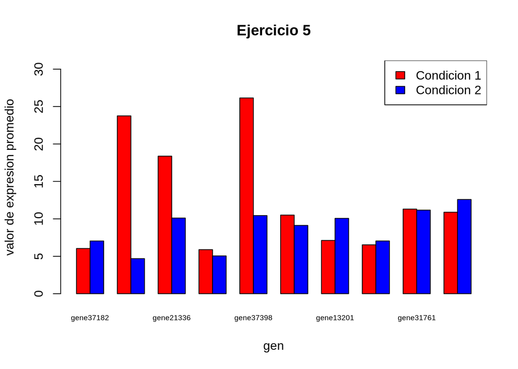

```r
# Selecciono aleatoriamente 10 nuevos genes
n_selec <- 10
genes_selec <- sample(n_genes, size=n_selec, replace=FALSE)

# Guardo la informacion de cada gen en vectores separados por condicion
prom_cond1 <- colMeans(expresion[, genes_selec, 1])
prom_cond2 <- colMeans(expresion[, genes_selec, 2])

# Creo una matriz con los vectores de las condiciones
matriz_cond <- rbind(prom_cond1, prom_cond2)

# Utilizando la matriz, creo una grafica de barras
barplot(matriz_cond,

        # Modifico la documentacion de la grafica
        main="Ejercicio 5", names.arg=genes[genes_selec], cex.names=0.6, xlab="gen", ylab="valor de expresion promedio",

        # Modifico las caracteristicas de la grafica
        col=c("red", "blue"), beside=TRUE, ylim = c(0, max(matriz_cond)+5))

# Creo una leyenda para la grafica
legend("topright", c("Condicion 1","Condicion 2"), fill = c("red","blue"))
```

**(2 puntos) Ejercicio 6: Calcula el estadístico *t* para comparar cuantitativamente los promedios de expresión de todos los genes en ambas condiciones. El estadístico *t* se calcula de la siguiente manera:**

$$t := \frac{M_{1} - M_{2}}{\sqrt{\frac{V_{1}}{14}+\frac{V_{2}}{14}}}$$

**donde *M1* y *M2* son los promedios de expresión de un gen en la condición 1 y la condición 2 respectivamente, y *V1* y *V2* son las varianzas correspondientes (puedes revisar *t-test* - aunque no es necesario entenderlo por completo en este momento-). Los genes cuyo valor del estadístico *t* sea tal que *|t|>3* son genes cuyo promedio de expresión difiere significativamente entre ambas condiciones. Obtén los nombres de los genes con expresión diferencial y guárdalos en un archivo.**

```r
# Creo una funcion que calcula el estadistico t
calcular_t <- function(a){

  # Calculo el promedio de expresion de cada gen en cada condicion
  M1 <- colMeans(a[, , 1])
  M2 <- colMeans(a[, , 2])

  # Calculo la varianza de la expresion de cada gen en cada condicion
  V1 <- apply(a[, , 1], MARGIN=2, var)
  V2 <- apply(a[, , 2], MARGIN=2, var)

  # Calculo y retorno el estadistico t
  t <- (M1-M2)/sqrt((V1/14) + (V2/14))
  return(t)
}

# Calculo los valores absolutos del resultado del estadistico t
t_values <- abs(calcular_t(expresion))

# Imprimo como resultado el nombre de los genes con expresion diferencial mayor al umbral
genes_test <- genes[t_values > 3]
head(genes_test, 20)
```

```
##  [1] "gene1"  "gene4"  "gene5"  "gene6"  "gene13" "gene18" "gene19" "gene21"
##  [9] "gene22" "gene28" "gene31" "gene35" "gene38" "gene40" "gene43" "gene49"
## [17] "gene54" "gene56" "gene57" "gene59"
```

```r
# Escribo los resultados en un archivo externo
write.table(genes_test, file='/home/salvador/Documentos/Licenciatura_Ciencias_Genomicas/Tercer_Semestre/Curso_R/Tarea3_Ejercicio6.txt', append=FALSE)
```

**(1 punto) Ejercicio 7: Obtén los valores del estadístico *t* de todos los genes Activador y grafícalos en un histograma. Ver la ayuda de la función *hist*.**

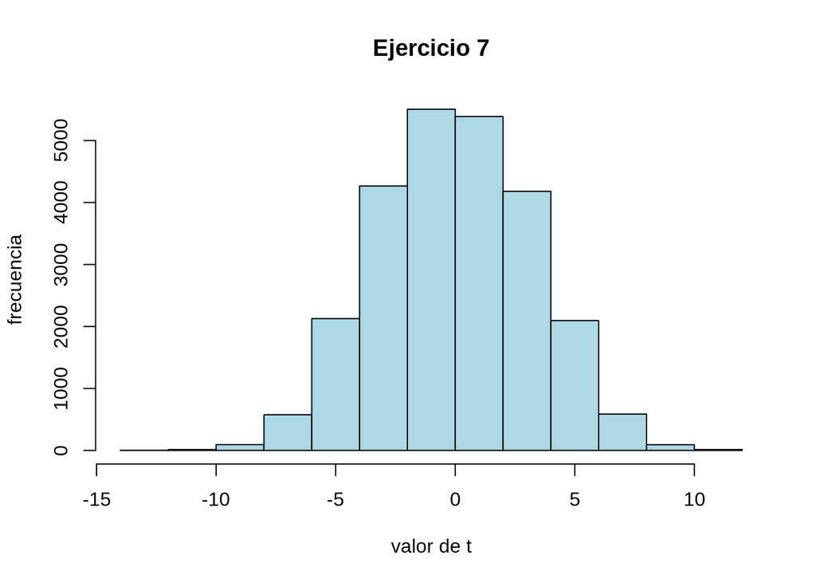

```r
# Calculo el estadistico t de cada gen
t_values <- calcular_t(expresion)

# Realizo un histograma con los resultados del estadistico t de los genes activadores
hist(t_values[categoria == 'Activador'],

     # Modifico la documentacion de la grafica
     main='Ejercicio 7', xlab='valor de t', ylab='frecuencia',

     # Modifico el color del histograma
     col='lightblue')
```

**(2 puntos) Ejercicio 8: Obtén los valores del estadístico *t* de todos los genes para cada una de las categorías: Activador, Represor y Ambivalente, y realiza tres gráficas *boxplot* en una misma figura, una para cada una de sus distribuciones. Ver la ayuda de la función *boxplot*.**

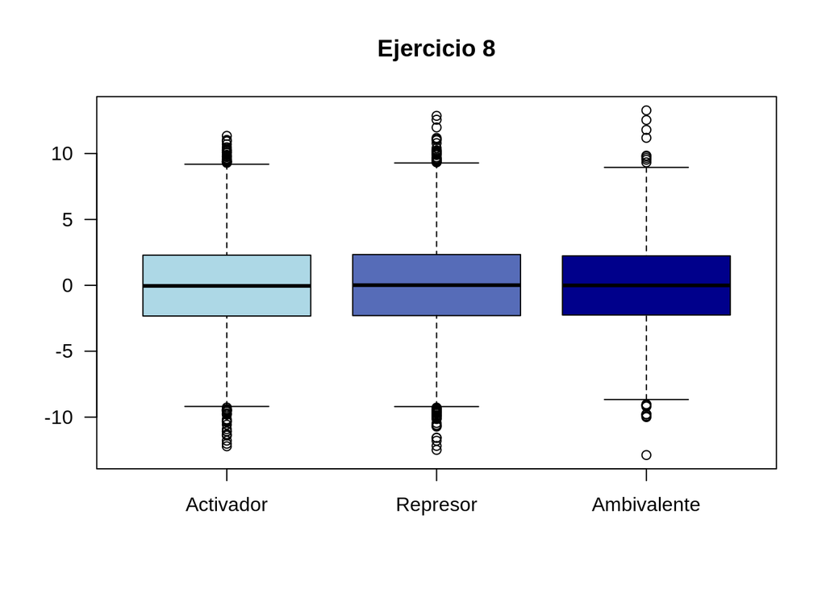

```r
# Guardo los valores de t pertenecientes a cada categoria
t_activador <- t_values[categoria == 'Activador']
t_represor <- t_values[categoria == 'Represor']
t_ambivalente <- t_values[categoria == 'Ambivalente']

# Creo un gradiente de colores para usar en las graficas
gradiente <- colorRampPalette(c('lightblue','darkblue'))

# Genero un boxplot con los valores de t para cada categoria
boxplot(t_activador, t_represor, t_ambivalente,

        # Modifico la documentacion de la grafica
        main='Ejercicio 8', names=c('Activador', 'Represor', 'Ambivalente'),

        # Modifico las caracteristicas de las graficas
        at=c(1,2,3), las=1, col=gradiente(3), horizontal = FALSE)
```

**(2 puntos) Ejercicio 9: Obtén los valores del estadístico *t* de todos los genes en cada una de las categorías por separado. Compara los 3 histogramas correspondientes, junto con el histograma obtenido al tomar todos los genes como un solo conjunto, en un solo device (en una sola imagen).**

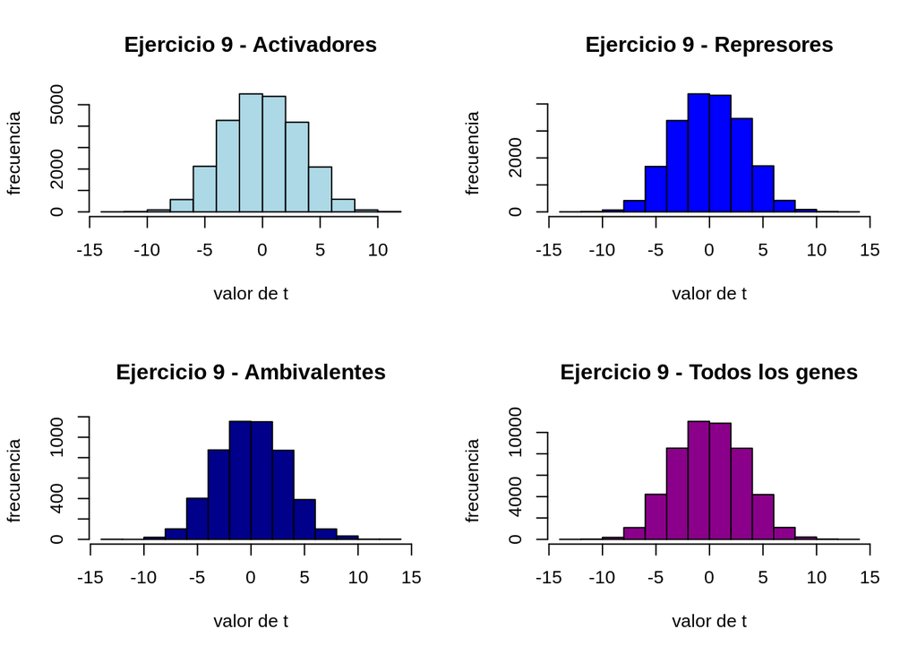

```r
# Preparo el device para dibujar 4 graficas en la misma figura
layout(matrix(c(1,2,3,4), nrow=2, byrow=TRUE))

# Genero los histogramas con los valores del estadistico t separados por cada categoria
hist(t_activador, main='Ejercicio 9 - Activadores', xlab='valor de t', ylab='frecuencia', col='lightblue')
hist(t_represor, main='Ejercicio 9 - Represores', xlab='valor de t', ylab='frecuencia', col='blue')
hist(t_ambivalente, main='Ejercicio 9 - Ambivalentes', xlab='valor de t', ylab='frecuencia', col='darkblue')

# Gennero el histograma con todos los valores del estadistico t
hist(t_values, main='Ejercicio 9 - Todos los genes', xlab='valor de t', ylab='frecuencia', col='darkmagenta')
```

**(1 punto) Ejercicio 10: Para cada una de las categorías obtén el número de genes tales que *|Z|>3* y después compararlos utilizando una gráfica de pie (función *pie*).**

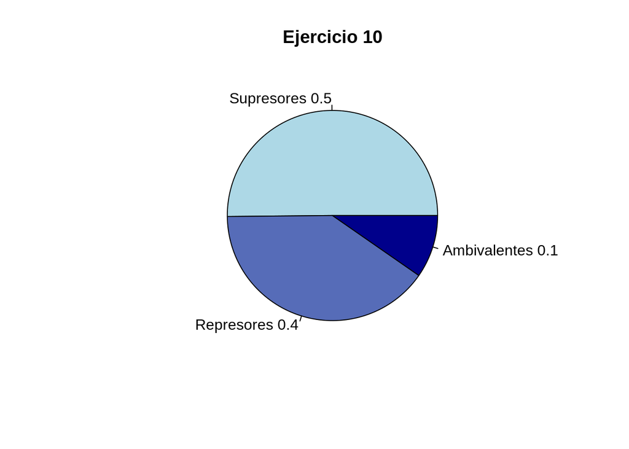

```r
# Calcula el numero de valores t superiores al umbral para cada categoria
total_activador <- length(t_activador[t_activador > 3])
total_represor <- length(t_represor[t_represor > 3])
total_ambivalente <-length(t_ambivalente[t_ambivalente > 3])

# Calcula el numero de valores de t superiores al umbral
total_genes <- length(t_values[t_values > 3])

# Genero una grafica pie con las cantidades anteriores
pie(c(total_activador, total_represor, total_ambivalente),

    # Modifico el color de cada zona del pie
    col = gradiente(3),

    # Modifico la documentacion de la grafica, incluyendo la proporcion de cada categoria en el pie
    main='Ejercicio 10',
    labels=c(paste('Supresores', round(total_activador/total_genes, 2)),
             paste('Represores', round(total_represor/total_genes, 2)),
             paste('Ambivalentes', round(total_ambivalente/total_genes, 2))))
```